# Event Driven Pricing Game

#### The Market

- The demand that firm $i$ faces is given by $Q_i = a_s-\beta p_i +\gamma p_j$, where $a$ is determined by the state of the market.
- The market spontaneously changes state at a rate of $\lambda_m$
- The market informs each player of the state by sending messages to player 1 and player 2 at a rate of $\mu_1$ and $\mu_2$, respectively.

#### Players

- 2 human controlled SFTs that represent firms
- The players only have one state
- The players choose a price upon receiving a message from the market by sending messages to the market. Prices go to market at a rate of $\nu_1$ and $\nu_2$.
- In short, the player's can receive messages from the market at different times and their messages (which are quantities) can reach the market at different times.

#### Equilibrium

- The price is determined by the state of the market and the most recent message from both players.
- Rewards are accumulated as profit, computed as $P\times Q-CQ$, per unit time. $C$ is an exogenously specified per-unit cost.

#### Other Points

- The game is infinite horizon
- Rewards are discounted

### Imports

```julia
using PyCall
@pyimport adsy.display as ad
ad.extended_styles()
```

Toggle Input

```julia
using StatsBase
using Distributions
using PyPlot
```

```
INFO: Loading help data...
```

### Message Type

```julia
# A Message Event in an SFT-Net
type Message
    sender::ASCIIString
    receiver::ASCIIString
    content::Any
    rate::Float64
end
```

### Spontaneous Event Type

```julia
type Spont
    sftname::ASCIIString
    rate::Float64
    newstate::Any # The state the node changes to
    messagesout::Array{Message, 1} # Messagges spontaneously emitted
end
```

### Player Type

```julia
## A Player in the Cournot Game
type Player
    discount::Float64 # Discount Rate
    messages::Array{Message, 1} # List of messages or message set!
    cost::Float64 # Per unit Cost

    ############################# ACTION NEEDS TO BE REDEFINED TO BE A STRATEGY! ###
    strategy::Dict{(Message, Any), (Message, Any)} # CHANGE THIS TO ANY ANY SINCE MESSAGES MIGHT BE AN ARRAY


    statespace::Array{Any, 1} # The state space
    currentstate::Any
    price_since_last_event::Float64
    name::ASCIIString
    trembling::Bool
    trembleprob::Float64
    ## Technically, quantitysincelastevent is a deterministic
    ## element of the state space given the messages.  Here it is used
    ## for accounting purposes.  Last event is last event in the game.
end


# In general, the set of available actions should depend on the state/message received.  However, in
# this game, the player is only going to change his state and send messages and this will not depend
# on his current state or the message he receives.  Therefore, the elements of 'action' are probably going
# to be tuples of the form (Message, State Transition).  Therefore, we can define actions as the cross product of
# messages and states;
```

### Player Constructor

```julia
# Player Constructor
Player(discount, messages, cost, strategy, statespace, name, trembling, trembleprob) = Player(
                                                discount, messages,  cost,
                                                strategy,
                                                statespace,
                                                statespace[1], 0.,
                                                name, trembling, trembleprob);
# If no manipulation of a type's argumens are required, it makes sense **not** to have a constructor.
# Otherwise, a constructor or an init function is necessary
# This constructor sets the MCTSvalues and MCTScounts as defaults

# Also, we will not include the messages upon initialization of the player
# instead, we will add messages to the player's message state once all SFTs are created
# from that we can generate the action space.;
```

### Player Functions

```julia
#### THIS FUNCTION NEEDS TO BE TOTALLY REWRITTEN SO THAT IT JUST PLAYS
###  ACCORDING TO A STRATEGY

# But it should be as simple as changing the MCTSvalues dict to be the strategy
# In other words, if the strategy is a dictionary keyed by messages and states and it's values are
# tuples of actions and state changed

function receive_message_and_react(sft::Player, message::Message)
    #     This function will have a player receive a message and then emit
    #     a message and possibly change its state.  If the current state of the players
    #     and the received message has not yet occured for the player, the player will
    #     pick a message uniformly random.  If the player has received the message in
    #     his current state, he will do UCT.

    #     Note, this function does NOT update the MCTS nodes, it only picks the player's
    #     action.

    #     Output is a message.  The Player object may also change its currentstate method
    if ~ sft.trembling
        action = sft.strategy[message, sft.currentstate]
        sft.currentstate = action[2]
    else
        if rand() < sft.trembleprob
            action = (sample(sft.messages), sample(sft.statespace))
            sft.currentstate = action[2]
        else
            action = sft.strategy[message, sft.currentstate]
            sft.currentstate = action[2]
        end
    end
    return action
end;
```

### Market Type

```julia
type Market
    rate::Float64 # Rate of spontaneous events transmission
    messages::Array{Message, 1} # The set of all possible message sets that can be released
    pricesinmarket::Dict{ASCIIString, Float64}
    statespace::Any # Now we just vary slope but can aslo vary intercept
    state::Any
    name::ASCIIString
    spont::Dict{Any, Any} # Spontaneous events keyed by current state of SFT
end
```

### Market Methods

```julia
# Market react to a message sent by a player
function receive_message_and_react(sft::Market, event::Message)
    sft.pricesinmarket[event.sender] = event.content
    return []
end;
```

```julia
# This is actually get quantity!
function get_quantities(sft::Market)
    p1q =  maximum([0, sft.state[1] - sft.state[2] * sft.pricesinmarket["Player 1"] + sft.state[3] * sft.pricesinmarket["Player 2"]])
    p2q =  maximum([0, sft.state[1] - sft.state[2] * sft.pricesinmarket["Player 2"] + sft.state[3] * sft.pricesinmarket["Player 1"]])
    return (p1q, p2q)
end;
```

```julia
function receive_message_and_react(sft::Market, event::Spont)
    sft.state = event.newstate
    return event.messagesout
end;
```

### SFTNet Type

```julia
type SFTNet
    players::Array{Player, 1}
    market::Market
    messagesintransit::Array{Message, 1}
    sftdict::Dict
end
```

### SFTNet-Methods

```julia
function resetnet(net::SFTNet)
    net.market.state = net.market.statespace[1]
    net.messagesintransit = Message[]
    for p in net.players
        net.market.pricesinmarket[p.name] = 0
        p.price_since_last_event = 0
    end
end;
```

### Functions Called During Simulation

```julia
function handle_event(event::Any, net::SFTNet)
    if typeof(event) == Spont
        return receive_message_and_react(net.market, event)
    elseif event.receiver=="Market"
        return receive_message_and_react(net.market, event)
    else
        return receive_message_and_react(net.sftdict[event.receiver], event)
    end
end;
```

```julia
function get_possible_events(net::SFTNet)
    return [net.messagesintransit, net.market.spont[net.market.state]]
end;
```

```julia
function get_time_increment(possible_events::Array)
    sumrate = sum([e.rate for e in possible_events])
    return rand(Exponential(1/sumrate))
end;
```

```julia
function generate_random_strategy(messages_to_send::Array{Message, 1}, messages_to_receive::Array{Message, 1},
    statespace)
    strategy = Dict{(Message, Any), (Message, Any)}()
    for instate in statespace
        for m_in in messages_to_receive
            messageout = sample(messages_to_send)
            newstate = sample(statespace)
            strategy[(m_in, instate)] = (messageout, newstate)
        end
    end
    return strategy
end;
```

```julia
# THIS ENTIRE CELL WILL HAVE TO BE DEFINED TO MAINTAIN
# GENERALITY IN THE CODE,  THIS INCLUDES MESSAGES GOING FROM
# PLAYER TO PLAYER, ETC.

## SPECIAL NOTE!!! FOR THE MARKET, WE DEFINE THE RATE OF EVENT FOR EACH
## POSSIBLE SPONTANEOUS EVENT INSTEAD OF SPECIFYING A RATE OF SPONTANEOUS EVENTS
## AND A PI^SP.  IT TURNS OUT TO BE A TAD EASIER COMPUTATIONALLY.



#PARAMETERS#
mkt_to_p1 = 1.
mkt_to_p2 = 1.
market_state_space = [(50, 1, .5), (30, 1, .5),(10, 1, .5)]
p1quantities = [2:4:50]
p2quantities = [2:4:50]
p1tomarket = 1.
p2tomarket = 1.
p1statespace = ASCIIString["Memory1"]
p2statespace = ASCIIString["Memory1"]
market_change_rate = .25
discount=.25
p1c = 3.
p2c = 3.

#END PARAMETERS#

## Keep the nomenclatur here the same.  Just know quantities are prics
function build_net_for_experiment(mkt_to_p1::Float64, mkt_to_p2::Float64, market_state_space, p1quantities,
    p2quantities, p1tomarket::Float64, p2tomarket::Float64, p1statespace, p2statespace, market_change_rate::Float64,
    discount::Float64, p1c, p2c, trembling=false, trembleprob=0.0)
    # DEFINE AND COLLECT ALL POSSIBLE MESSAGES IN THE GAME#
    p1messages = Message[]
    p2messages = Message[]
    marketmessages = Message[]
    # First let's generate market messages to each player
    for s in market_state_space
        push!(marketmessages, Message("Market", "Player 1", s, mkt_to_p1))
        push!(marketmessages, Message("Market", "Player 2", s, mkt_to_p2))
    end

    for q in p1quantities
        push!(p1messages, Message("Player 1", "Market", q, p1tomarket))
    end

    for q in p2quantities
        push!(p2messages, Message("Player 2", "Market", q, p2tomarket))
    end
    # Now generate message from players to market
    # END DEFINE ALL MESSAGES#

    ## DEFINE AND COLLECT ALL SPONTANEOUS EVENTS FOR THE MARKET
    market_spon_dict = Dict()
    ## The market is a random walk on the index of the statespace
    ## Therefore, when defining the statespace of the market, it makes sense to
    ## "order" the states.
    for ix in 1:length(market_state_space)
        if ix ==1
            market_spon_dict[market_state_space[ix]] = Spont[]
            s_event = Spont("Market", market_change_rate, market_state_space[2], marketmessages[3:4])
            push!(market_spon_dict[market_state_space[ix]], s_event)

        elseif ix == length(market_state_space)
            market_spon_dict[market_state_space[ix]] = Spont[]
            s_event = Spont("Market", market_change_rate, market_state_space[(length(market_state_space) -1)],
                [marketmessages[(length(marketmessages) - 3) : (length(marketmessages) - 2)]])
            push!(market_spon_dict[market_state_space[ix]], s_event)
        else
            start_ix = 2*ix +1
            end_ix = 2*ix+2
            market_spon_dict[market_state_space[ix]] = Spont[]
            s_event = Spont("Market", market_change_rate/2., market_state_space[(ix+1)],
                [marketmessages[start_ix : end_ix]])
            push!(market_spon_dict[market_state_space[ix]], s_event)
            start_ix = 2*ix-3
            end_ix = 2*ix-2
            s_event = Spont("Market", market_change_rate/2., market_state_space[(ix+-1)],
                [marketmessages[start_ix : end_ix]])
            push!(market_spon_dict[market_state_space[ix]], s_event)
        end
    end
    ## END MARKET SPONTANEOUS EVENTS

    # This is annoying because Julia does not have conditional list comprehension
    messages_to_p1 = Message[]
    messages_to_p2 = Message[]
    for m in marketmessages
        if m.receiver=="Player 1"
            push!(messages_to_p1, m)
        else
            push!(messages_to_p2, m)
        end
    end
    p1_strategy = generate_random_strategy(p1messages, messages_to_p1, p1statespace)
    p2_strategy = generate_random_strategy(p2messages, messages_to_p2, p2statespace)
    qinmarket = ["Player 1"=>1, "Player 2"=>1]
    #CREATE SFTs#
    p1 = Player(discount, p1messages, p1c, p1_strategy, p1statespace, "Player 1", trembling, trembleprob);
    p2 = Player(discount, p2messages, p2c, p2_strategy, p2statespace, "Player 2", trembling, trembleprob);
    market = Market(market_change_rate, marketmessages, qinmarket, market_state_space, (50,1, .5), "Market", market_spon_dict)
    #END CREATE SFTs#
    sft_dict = {"Player 1"=> p1, "Player 2"=>p2, "Market"=>market}

    # CREATE AND INTIALIZE THE SFTNET#
    net = SFTNet([p1, p2], market, Message[], sft_dict)
    # END CREATE AND INITIALIZE THE SFTNET#;
    return net
end

# SET FUNCTION TO DETERMINE HOW MARKET RANDONLY CHANGES ITS STATE.
# MUST RETURN MESSAGE ARRAY OR NONE
net = build_net_for_experiment(mkt_to_p1, mkt_to_p2, market_state_space, p1quantities, p2quantities,
    p1tomarket, p2tomarket, p1statespace, p2statespace, market_change_rate, discount, p1c, p2c);
```

```julia
params = {"mkt_to_p1" => 1.,
          "mkt_to_p2" => 1.,
          "market_state_space" => [(50, 1), (50, 2),(50, 3)],
          "p1quantities" => [range(1,2,10)],
          "p2quantities" => [range(1,2,10)],
          "p1tomarket" => 1.,
          "p2tomarket" => 1.,
          "p1statespace" => ASCIIString["Memory1"],
          "p2statespace" => ASCIIString["Memory1"],
          "market_change_rate" => .25,
          "discount"=>.25,
          "p1c" => 1.,
          "p2c" => 1.,
          "numprofiles" => 2000,
          "numalt" => 30,
          "eunumsims" => 10000,
          "eu_tmax" =>20,
          "trembling"=> true,
          "tremble_prob"=>.1};
```

# A note on profits

We assume that profits are accumulated continuously. Therefore, total utility is given by \begin{equation} \int_0^\infty e^{-\beta t}\pi(t)dt. \end{equation}

However, profits only change when either the market changes state (demand shock) or a new product quantity is received by the market.  
Therefore, if we let $\tau_1, \tau_2...$ denote the times that the profit stream changes. Total utility is computed as

\begin{equation} \sum_{i=1}^{\infty}\int_{\tau_i}^{\tau_{i+1}} e^{-\beta t}\pi(t)dt. \end{equation}

where $\pi(t)$ is constant in any interval $(\tau_i, \tau_{i+1})$. This implies that for any interval, the contribution to total utility is given by

\begin{equation} \frac{e^{-\tau_i \beta} - e^{-\tau_{i+1} \beta}}{\beta}\pi \end{equation}

```julia
function get_profits(net::SFTNet, tau1::Float64, tau2::Float64)
    quantities = get_quantities(net.market)
    p1_profit = quantities[1] * net.market.pricesinmarket["Player 1"] -
        net.sftdict["Player 1"].cost * quantities[1]
    p2_profit = quantities[2] * net.market.pricesinmarket["Player 2"] -
    net.sftdict["Player 2"].cost * quantities[2]
    p1_discounted_profit = ( (e^(-tau1 * net.sftdict["Player 1"].discount) - e^(-tau2 * net.sftdict["Player 1"].discount)) *
            p1_profit) /net.sftdict["Player 1"].discount
    p2_discounted_profit = ( (e^(-tau1 * net.sftdict["Player 2"].discount) - e^(-tau2 * net.sftdict["Player 2"].discount)) *
            p2_profit) /net.sftdict["Player 2"].discount
    return [p1_discounted_profit, p2_discounted_profit]
end;
```

```julia
# Use some of this!
function simulate(net::SFTNet, t_end::Int64)
    t = 0.
    total_profits = [0,0]
    possible_events = get_possible_events(net)
    while t < t_end
        probs = WeightVec(Float64[e.rate for e in possible_events])
        event = sample(possible_events, probs)
        #print(event, "\n \n")
        # An event is either a spontaneous transm/transi or a message received
        if (typeof(event)==Message)
            ix = findfirst(net.messagesintransit, event)
            splice!(net.messagesintransit, ix) # Removes the messge from the network
            # If the event is the player receiving a message
            if event.sender == "Market"
                player = net.sftdict[event.receiver]
                # "player" is now the Player type
                action = handle_event(event, net)
                new_messages = action[1]
                net.messagesintransit = [net.messagesintransit, new_messages]
            else
                # If the event is the market receiving a message
                handle_event(event, net) # The market changes quantities in market
            end
        else
            new_messages = handle_event(event, net)
            net.messagesintransit = [net.messagesintransit, new_messages]
        end
        possible_events = get_possible_events(net)
        timeincrement = get_time_increment(possible_events)
        immediate_profits = get_profits(net, t, t+timeincrement)
        t += timeincrement
        total_profits += immediate_profits
    end
    return total_profits
end;
```

```julia
net = build_net_for_experiment(mkt_to_p1, mkt_to_p2, market_state_space, p1quantities, p2quantities,
p1tomarket, p2tomarket, p1statespace, p2statespace, market_change_rate, discount, p1c, p2c);
simulate(net,30);
```

```julia
function compute_expected_utility(net::SFTNet, t_max::Int64, nruns::Int64)
    eu = [0,0]
    for s in 1:nruns
        eu += simulate(net, t_max)
    end
    return eu/nruns
end;
```

# Initial Parameters

### Pre-PGT experiments

Although the game continues to infinity, because of a positive discount rate, the expected utilities should converge. Let's take a look and see what expected utility looks like for a given joint profile and different lengths of simulation. In this example we simulate the network 5000 times to estimate expected utility.

Again, this has nothing to do with PGT. Since the game is of infinite horizon, these simulations are meant to determine how many time steps is "enough" so that the expected utility is "close" to the expected utility if the game were to run until infinity.

```julia
net = build_net_for_experiment(mkt_to_p1, mkt_to_p2, market_state_space, p1quantities, p2quantities,
p1tomarket, p2tomarket, p1statespace, p2statespace, market_change_rate, discount, p1c, p2c);
eus = Array[]
for i in 5:5:50
    push!(eus, compute_expected_utility(net, i, 5000))
end
```

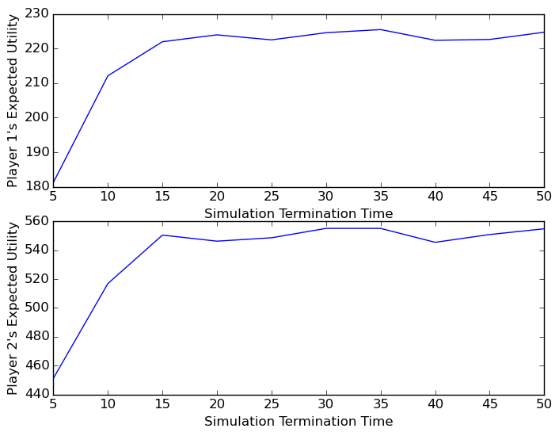

```
PyObject <matplotlib.text.Text object at 0x7fd899fb69d0>
```

```julia
p1eu = [x[1] for x in eus];
p2eu = [x[2] for x in eus];
fig = figure("A new figure")
subplot(211)
plot(5:5:50,p1eu)
xlabel("Simulation Termination Time")
ylabel("Player 1's Expected Utility")
subplot(212)
plot(5:5:50, p2eu)
xlabel("Simulation Termination Time")
ylabel("Player 2's Expected Utility")
```

It looks like the expected utility becomes stationary around 20 time steps.

```julia
eus2 = Array[]
for i in [1000:5000:100000]
    push!(eus2, compute_expected_utility(net, 20, i))
end
```

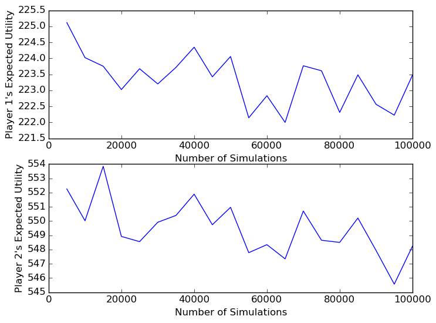

```julia
p1eu2 = [x[1] for x in eus2];
p2eu2 = [x[2] for x in eus2];
fig = figure("A new figure")
subplot(211)
plot([5000:5000:100000], p1eu2)
xlabel("Number of Simulations")
ylabel("Player 1's Expected Utility")
subplot(212)
plot( [5000:5000:100000], p2eu2)
xlabel("Number of Simulations")
ylabel("Player 2's Expected Utility");
```

We can also look at the relative error which is computed as \begin{equation} \frac{\big|(\text{expected utility after n samples)-(expected utility after 100000 samples})\big|}{(\text{expected utility after 100000 samples})} \end{equation} for $n=1,2...100000$. $n$ is the x axis in the plots below.

[figure not shown]

```julia
p1mean = mean(p1eu2)
p2mean = mean(p2eu2)
fig = figure("A new figure")
subplot(211)
plot([500:500:100000], (((p1mean-p1eu2).^2).^.5)/p1mean)
hlines(.01, 0, 100000)
xlabel("Number of Simulations")
ylabel("Relative Error")
subplot(212)
plot( [500:500:100000], (((p2mean-p2eu2).^2).^.5)/p2mean)
hlines(.01, 0, 100000)
xlabel("Number of Simulations")
ylabel("Relative Error");
```

It still seems that to get a relative error less than 1% we need about 40000 simulations. Let's see how long that takes.

```julia
net = build_net_for_experiment(mkt_to_p1, mkt_to_p2, market_state_space, p1quantities, p2quantities,
p1tomarket, p2tomarket, p1statespace, p2statespace, market_change_rate, discount, p1c, p2c);
eus2 = Array[]
for i in [1000:1000:10000]
    push!(eus2, compute_expected_utility(net, 20, i))
end
```

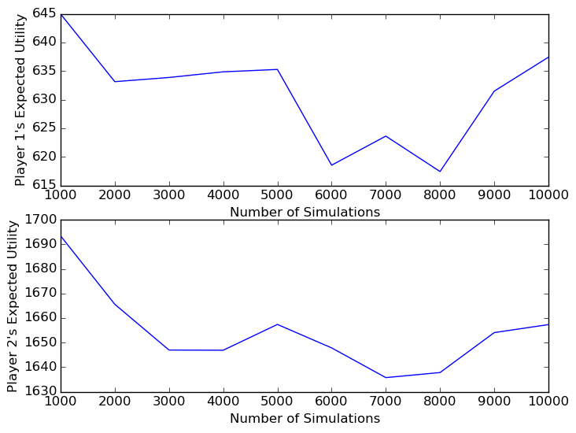

```julia
p1eu2 = [x[1] for x in eus2];
p2eu2 = [x[2] for x in eus2];
fig = figure("A new figure")
subplot(211)
plot([1000:1000:10000], p1eu2)
xlabel("Number of Simulations")
ylabel("Player 1's Expected Utility")
subplot(212)
plot( [1000:1000:10000], p2eu2)
xlabel("Number of Simulations")
ylabel("Player 2's Expected Utility");
```

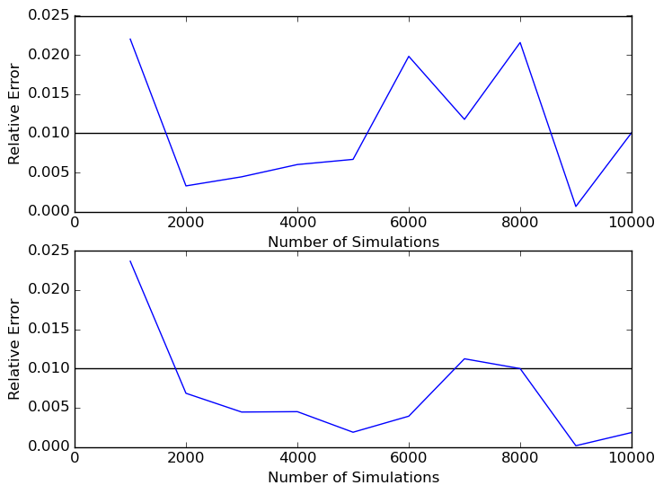

```julia
p1mean = mean(p1eu2)
p2mean = mean(p2eu2)
fig = figure("A new figure")
subplot(211)
plot([1000:1000:10000], (((p1mean-p1eu2).^2).^.5)/p1mean)
hlines(.01, 0, 10000)
xlabel("Number of Simulations")
ylabel("Relative Error")
subplot(212)
plot( [1000:1000:10000], (((p2mean-p2eu2).^2).^.5)/p2mean)
hlines(.01, 0, 10000)
xlabel("Number of Simulations")
ylabel("Relative Error");
```

```julia
@time compute_expected_utility(net, 20, 20000)
```

```
elapsed time: 7.322022892 seconds (2379959760 bytes allocated, 16.55% gc time)
```

[output not shown]

# Confidence Interval PGT

1) Sample a joint strategy profile and compute the expected utility "almost exactly" (i.e. with a large number of runs).

2) For each alternative joint strategy profile, begin sampling the stochastic process to compute the expected utility.

3) (Suppose we are computing the intelligence for player 1's profile). After each sample of the network, compute the confidence interval of player 1's expected utility under his alternative strategy at a pre-specified significance level.

4) If the expected utility of player 1's "outerloop" strategy is outside of the confidence interval of player 1's expected utility under the alternative strategy, classify the alternative strategy as either better or worse than the outerloop strategy according to whether the outerloop strategy is above or below the confidence interval.

5) Set a predefined maximum number of simulations in case the outerloop expected utility is never outside of the confidence interval.

```julia
function is_worse(net::SFTNet, t_max::Int64, nruns::Int64, baseeu::Float64, player::Int64,
    confintmin=50, z=2.576)
    ## The player is the index to compare in the simulate output.
    runningeu = 0
    sse = 0
    s = 1
    running_sum_squares= 0
    while s < nruns
        utility = simulate(net, t_max)[player]
        e = utility - runningeu
        runningeu += e/s
        sse += e* (utility - runningeu)
        variance = sse/s
        s += 1
        if s >confintmin
            # confintmin large enough so that we can approximate the mean by a normal distribution, not t.
            conf_l = runningeu - z*(variance/s)^.5
            conf_u = runningeu + z*(variance/s)^.5
            if (baseeu < conf_l) | (baseeu>conf_u)
                s = nruns #Exit Loop
            end
        end
    end
    return runningeu
end;
```

```julia
function CI_PGT(paramdict::Any)
    mkt_to_p1 = paramdict["mkt_to_p1"]
    mkt_to_p2 = paramdict["mkt_to_p2"]
    market_state_space = paramdict["market_state_space"]
    p1quantities = paramdict["p1quantities"]
    p2quantities = paramdict["p2quantities"]
    p1tomarket = paramdict["p1tomarket"]
    p2tomarket = paramdict["p2tomarket"]
    p1statespace = paramdict["p1statespace"]
    p2statespace = paramdict["p2statespace"]
    market_change_rate = paramdict["market_change_rate"]
    discount= paramdict["discount"]
    p1c = paramdict["p1c"]
    p2c = paramdict["p2c"]
    numprofiles = paramdict["numprofiles"]
    numalt = paramdict["numalt"]
    eu_nsims = paramdict["eunumsims"]
    eu_tmax = paramdict["eu_tmax"]
    tremble = paramdict["trembling"]
    tremble_prob = paramdict["tremble_prob"]

    net = build_net_for_experiment(mkt_to_p1, mkt_to_p2, market_state_space, p1quantities, p2quantities,
                                    p1tomarket, p2tomarket, p1statespace, p2statespace, market_change_rate,
                                        discount, p1c, p2c, tremble, tremble_prob)
    messages_to_p1 = Message[]
    messages_to_p2 = Message[]
    for m in net.market.messages
        if m.receiver=="Player 1"
            push!(messages_to_p1, m)
        else
            push!(messages_to_p2, m)
        end
    end
    # Get these at the beginning so we don't have to keep searching player types
    p1possible = net.sftdict["Player 1"].messages
    p2possible = net.sftdict["Player 2"].messages
    p1statespace = net.sftdict["Player 1"].statespace
    p2statespace = net.sftdict["Player 2"].statespace
    sampled_strats = Any[]
    p1_utilities = Float64[]
    p2_utilities = Float64[]
    intels = Float64[]
    for jps in 1:numprofiles
        p1_strategy = generate_random_strategy(p1possible, messages_to_p1,
            p1statespace)
        p2_strategy = generate_random_strategy(p2possible, messages_to_p2,
            p2statespace)
        ## Need to compute twice, on for player 1 trembing and one for player 1
        push!(sampled_strats, (p1_strategy, p2_strategy))
        net.sftdict["Player 1"].strategy = p1_strategy
        net.sftdict["Player 2"].strategy = p2_strategy
        #Player 1
        net.sftdict["Player 1"].trembling=false
        net.sftdict["Player 2"].trembling=true
        eu_outer = compute_expected_utility(net, eu_tmax, eu_nsims)
        push!(p1_utilities, eu_outer[1])
        #Player 2
        net.sftdict["Player 1"].trembling=true
        net.sftdict["Player 2"].trembling=false
        eu_outer = compute_expected_utility(net, eu_tmax, eu_nsims)
        push!(p2_utilities, eu_outer[2])

        #joint_strats_eu[p1_strategy, p2_strategy] = eu_outer
        num_no_betterp1 = 0
        num_no_betterp2 = 0
        for a in 1:numalt
            net.sftdict["Player 1"].trembling=false
            net.sftdict["Player 2"].trembling=true
            p1altstrat = generate_random_strategy(p1possible, messages_to_p1,
                p1statespace)
            net.sftdict["Player 1"].strategy = p1altstrat
            eu_inner = is_worse(net, eu_tmax, eu_nsims, eu_outer[1], 1)
            if eu_inner < eu_outer[1]
                num_no_betterp1 += 1
            end
        end
        net.sftdict["Player 1"].strategy = p1_strategy
        for a in 1:numalt
            net.sftdict["Player 1"].trembling=true
            net.sftdict["Player 2"].trembling=false
            p2altstrat = generate_random_strategy(p2possible, messages_to_p2,
                p2statespace)
            net.sftdict["Player 2"].strategy = p2altstrat
            eu_inner = is_worse(net, eu_tmax, eu_nsims, eu_outer[2], 2)
            if eu_inner < eu_outer[2]
                num_no_betterp2 += 1
            end
        end
        intel = (num_no_betterp1/numalt) * (num_no_betterp2/numalt)
        push!(intels, intel)
    end
    return intels, p1_utilities, p2_utilities, sampled_strats
end;
```

```julia
function split_pgt_parallel(pgtres)
    intels = Float64[]
    p1util = Float64[]
    p2util = Float64[]
    strats = Any[]
    for core in pgtres
        for simnum in 1:length(core[1])
            if ~ (core[4][simnum] in strats)
                push!(strats, core[4][simnum])
                push!(intels, core[1][simnum])
                push!(p1util, core[2][simnum])
                push!(p2util, core[3][simnum])
            end
        end
    end
    return strats, intels, p1util, p2util
end
```

```
split_pgt_parallel (generic function with 1 method)
```

```julia
addprocs(7)
@everywhere require("SimpleBertrandParallel.jl");
```

[output not shown]

```julia
params = {"mkt_to_p1" => 1.,
          "mkt_to_p2" => 1.,
          "market_state_space" => [(50, 1, .5), (30, 1, .5),(10, 1,.5)],
          "p1quantities" => [2:4:50],
          "p2quantities" => [2:4:50],
          "p1tomarket" => 1.,
          "p2tomarket" => 1.,
          "p1statespace" => ASCIIString["Memory1"],
          "p2statespace" => ASCIIString["Memory1"],
          "market_change_rate" => .25,
          "discount"=>.25,
          "p1c" => 1.,
          "p2c" => 1.,
          "numprofiles" => 5000,
          "numalt" => 30,
          "eunumsims" => 1000,
          "eu_tmax" =>20,
          "trembling"=> true,
          "tremble_prob"=>.1};
```

```julia
ci_result = pmap(CI_PGT, [params, params, params, params, params, params, params]);
```

```julia
splitup = split_pgt_parallel(ci_result);
```

Using this confidence interval approach, we are indeed able to get results!